# Walmart Sales Prediction

Sebastian Alvarado

August 14, 2016

# Introduction

Predicting future sales for a company is one of the most important aspects of strategic planning. We would like to analyze how internal and external factors of one of the biggest companies in the US can affect their Weekly Sales in the future. This model tries to achieve an approximate weekly sales prediction looking at previous years performance per Store on a weekly basis.

The data collected ranges from 2010 to 2012, where 45 Walmart stores across the country were included in this analysis. It is important to note that we also have external data available like CPI,Unemployment Rate and Fuel Prices in the region of each store which, hopefully, help us to make a more detailed analysis.

To learn more about Walmart and what is their business model you can read about the company [here](https://en.wikipedia.org/wiki/Walmart).

# Data Explanation

We had access to four different data sets from Kaggle.com about the company. These data sets contained information about the stores,departments,temperature, unemployment etc. We will explain each one of the data sets in more detail with each one of its features.  
**Stores**:  
- Store: The store number. Range from 1-45.  
- Type: Three types of stores ‘A’, ‘B’ or ‘C’.  
- Size: Sets the size of a Store would be calculated by the no. of products available in the particular store ranging from 34,000 to 210,000.  
**Train**:  
-Date: The date of the week where this observation was taken . -Weekly_Sales: The sales recorded during that Week.  
-Store: The store which observation in recorded 1-45.  
-Dept: One of 1-99 that shows the department.  
-IsHoliday: Boolean value representing a holiday week or not.  
**Features**: -Temperature:Temperature of the region during that week.  
-Fuel_Price: Fuel Price in that region during that week.  
-MarkDown1:5 : Represents the Type of markdown and what quantity was available during that week.  
-CPI: Consumer Price Index during that week.  
-Unemployment: The unemployment rate during that week in the region of the store.

The test data have the same fields as the Train data, only the Weekly_Sales are empty.  
#Data Origin and Collection

```r
#Walmart Predictive Analysis
#Load Required Libraries

library(dplyr)
```

```r
library(ggplot2)
library(reshape2)
library(readr)
library(lubridate)
library(rpart)
library(rattle)
library(car)
library(caret)
library(corrplot)
library(rpart.plot)
```

Ensure that you have train.csv, test.csv, stores.csv and features.csv in your current working directory.

```r
#Loading files to work with
train<- read_csv("train.csv")
stores <- read_csv("stores.csv")
features <- read_csv("features.csv")
```

Our first step will be to join our two tables by Store which is the common column.

```r
stores$Store <- factor(stores$Store)
train$Store <- factor(train$Store)
train <- full_join(train,stores,by=c("Store"))
```

# Preparation

In this step of the process we will conduct some feature engineering, we will use the features that our data currently has but will tweak them in a way that makes our analysis easier. The most important objective in this step is to generate new features that will help us produce a better model **Include a Week Number of the year**

```r
train$WeekNum <- as.numeric(format(train$Date+3,"%U"))
```

We have also noticed that some Weekly Sales contain negative values, after analyzing the data we have concluded that those refer to Returned Products from previous weeks. **Add a Returns Column**

```r
train$Returns <- lapply(train$Weekly_Sales,function(sales){
  ifelse(sales < 0,sales,0)
})
train$Weekly_Sales <- lapply(train$Weekly_Sales,function(sales){
  ifelse(sales > 0,sales,0)
})
```

At the moment, our data frame contains 421570 observations, since the objective of this model is to predict the Weekly Sales of a particular store given previous years, external information and tendency we will add the sales per department and put it together into one observation. In other words we will not subdivide sales by department. Thus we can make our Weekly Sales to be our Net Sales since we now can do Weekly_Sales - Returns to avoid negative values.  
##Aggregating Weekly Sales to Net Sales

```r
final_data <- data.frame(Store=factor(),Date=as.Date(character()),Weekly_Sales=numeric(),IsHoliday=logical(),Type=factor(),WeekNum=factor())
aggregate_sales <- function(){
for(i in 1:45){
  store_data <- train %>% filter(Store == i)
  dates <- unique(train$Date)
  for(next_date in seq_along(dates)){
    current_date <- unique(train$Date)[[next_date]]
    date_data <- store_data %>% filter(Date==current_date)
    #Add all the weekly sales
    net_sales <- unlist(sum(date_data$Weekly_Sales)) - unlist(sum(date_data$Returns))
    #Construct the data frame and append it
    next_row <- data.frame(Store=i,Date=current_date,Weekly_Sales=net_sales,IsHoliday=date_data$IsHoliday[[1]],Type=date_data$Type[[1]],WeekNum=date_data$WeekNum)
    next_row$Store <- factor(next_row$Store)
    final_data <- rbind(final_data,next_row)
  }
}
  return(final_data)
}
# Sum the sales by store without taking into account each department
final_data <- aggregate_sales()
```

After performing this procedure we now have 6435 observations which makes our data more manageable for further analysis.

```r
features$Store <- factor(features$Store)
#Merge our final_data with our features
train <- left_join(train,features,by=c("Store","Date","IsHoliday"))
# Make the NA markdown as 0
train$MarkDown1 <- sapply(train$MarkDown1, function(value){
  ifelse(is.na(value),0,value)
})
train$MarkDown2 <- sapply(train$MarkDown2, function(value){
  ifelse(is.na(value),0,value)
})
train$MarkDown3 <- sapply(train$MarkDown3, function(value){
  ifelse(is.na(value),0,value)
})
train$MarkDown4 <- sapply(train$MarkDown4, function(value){
  ifelse(is.na(value),0,value)
})
train$MarkDown5 <- sapply(train$MarkDown5, function(value){
  ifelse(is.na(value),0,value)
})
```

**Rank** We will also add a feature called rank, which is getting the range of values of Weekly Sales. We will make five Range Buckets namely A,B,C,D and E. We will also try to predict in which of this buckets a given store would lie in a given week.

We will partition the training set into two different data frames in order to keep our analysis consistent and avoid testing on our training data.

```r
#Subset our data into train and test
index <- createDataPartition(train$Weekly_Sales,list = FALSE,p=0.8)
train.train <-train[index,]
train.test <- train[-index,]
```

# Explortory Analysis

### Data Review

For a small glimpse of how our data looks like we can refer to the following picture.

```r
head(train.train)
```

```
## # A tibble: 6 x 17
##    Store       Date Weekly_Sales IsHoliday   Type WeekNum   Size
##   <fctr>     <date>        <dbl>     <lgl> <fctr>   <int>  <int>
## 1      1 2010-02-12      1641957      TRUE      A       7 151315
## 2      1 2010-02-19      1613694     FALSE      A       8 151315
## 3      1 2010-03-05      1554807     FALSE      A      10 151315
## 4      1 2010-03-12      1440938     FALSE      A      11 151315
## 5      1 2010-03-19      1472516     FALSE      A      12 151315
## 6      1 2010-03-26      1404430     FALSE      A      13 151315
## # ... with 10 more variables: Temperature <dbl>, Fuel_Price <dbl>,
## #   MarkDown1 <dbl>, MarkDown2 <dbl>, MarkDown3 <dbl>, MarkDown4 <dbl>,
## #   MarkDown5 <dbl>, CPI <dbl>, Unemployment <dbl>, Rank <fctr>
```

For our exploration analysis we started with the aggregate() function because we wanted to know which Store and Type of store was having the most sales, on average.

```r
aggregate(train.train[,"Weekly_Sales"], by=train.train[,c("Store"), drop=FALSE], mean)
```

```
##    Store Weekly_Sales
## 1      1    1545055.5
## 2      2    1926130.3
## 3      3     399771.8
## 4      4    2084247.4
## 5      5     315581.5
## 6      6    1555537.4
## 7      7     572077.3
## 8      8     916551.6
## 9      9     542848.0
## 10    10    1891728.7
## 11    11    1362391.9
## 12    12    1009782.9
## 13    13    2010356.0
## 14    14    2032062.7
```

[output cut: 31 more lines]

```r
aggregate(train.train[,"Weekly_Sales"], by=train.train[,c("Type"), drop=FALSE], mean)
```

```
##   Type Weekly_Sales
## 1    A    1374044.1
## 2    B     821474.4
## 3    C     474542.4
```

```r
aggregate(train.train[,"Weekly_Sales"], by=train.train[,c("Type"), drop=FALSE], max)
```

```
##   Type Weekly_Sales
## 1    A      3818686
## 2    B      3749058
## 3    C       725043
```

With this initial information, we wanted to dig a little deeper and that is why we decided that graphic models will help us to find the interaction between each of the variables with Weekly Sales. Our goal with this exploration was to find correlation, patterns or any other insight that revealed more information between diving into our predictive model.

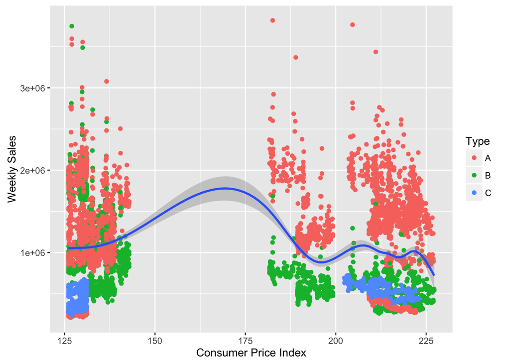

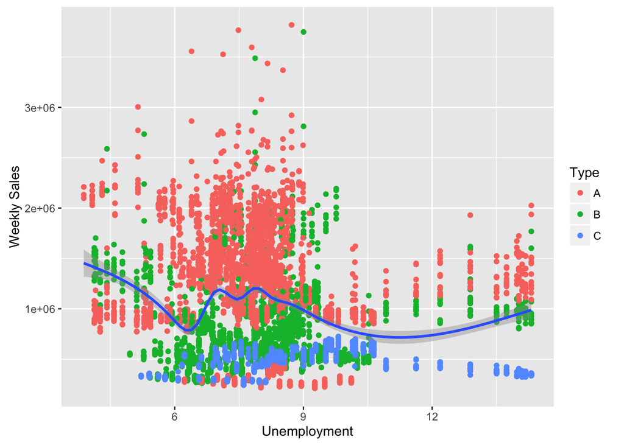

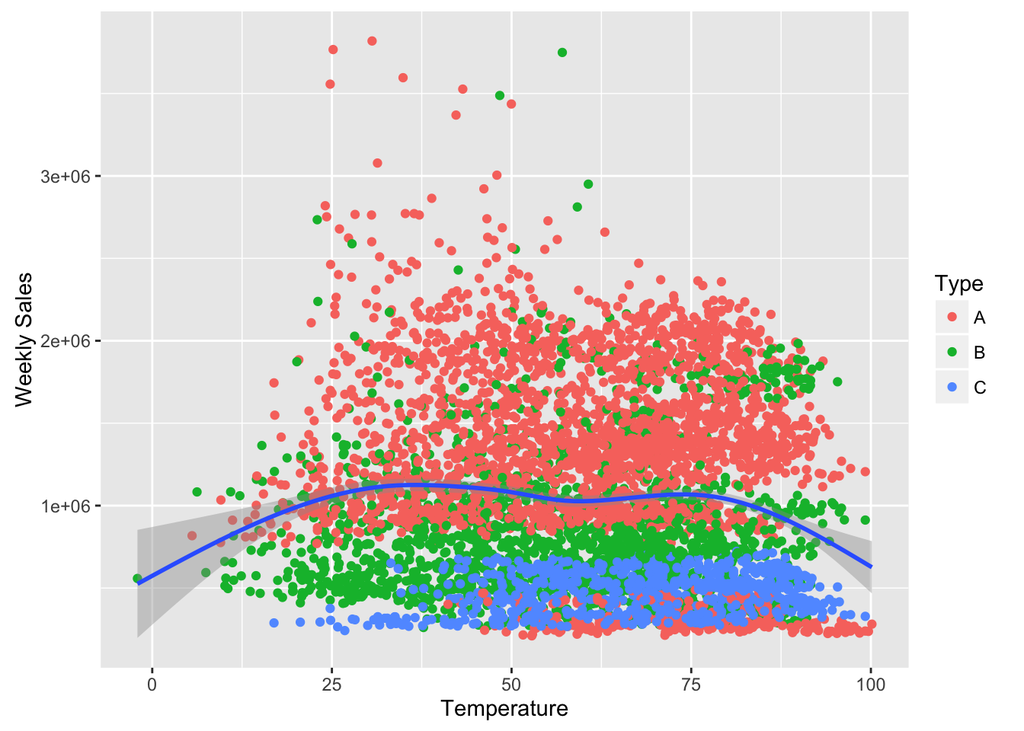

We also want to analyze what is the effect of the MarkDowns on the weekly sales of the company after analyzing the graphs we decided to show the one that had more impact. However, as one can see the MarkDowns don’t show an immense correlation with Sales.

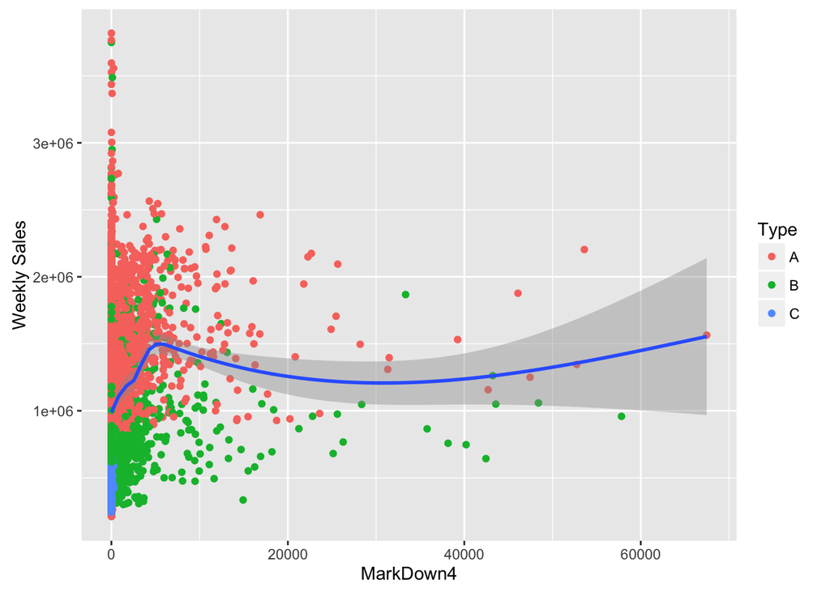

Plot Store sales divided by Type of Store, in the following plot we selected Type A stores

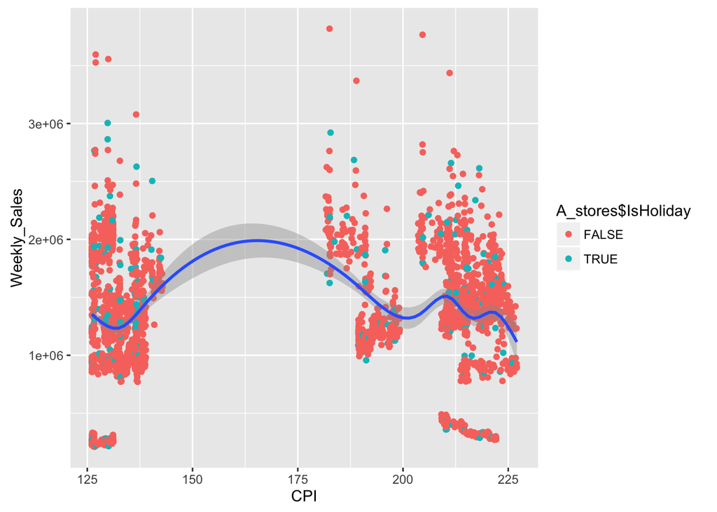

```r
A_stores <- train.train %>% filter(Type=='A')
ggplot(A_stores,aes(x=CPI,y=Weekly_Sales)) + geom_point(aes(color=A_stores$IsHoliday)) + geom_smooth()#Sales vary depending on the weeknum we are in
```

Now we want to partition the Weekly Sales based on a store, from our analysis we saw that Store 20 is the one with the most sales. We will analyze this stores’ results

```r
store_graph <- train.train %>% filter(Store == 20)
ggplot(store_graph,aes(x=CPI,y=Weekly_Sales)) + geom_point(aes(color=store_graph$IsHoliday)) + geom_smooth()
```

[output not shown]

Finally, look for a correlation matrix between all of our numerical features.

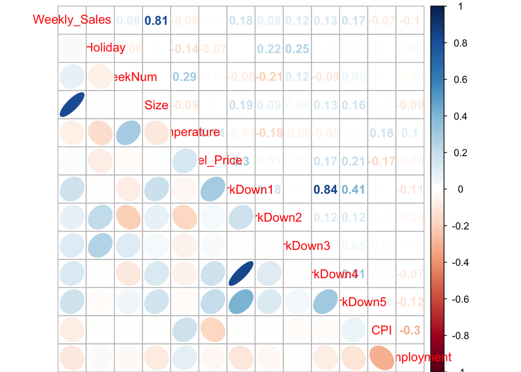

#Modelling Since we saw that the Store type is very important to predict the Weekly Sales of a given store, we will run a Decision Tree model to predict what Type a Store should be based on the different features that we have on our model.  
**Decision Tree**

```r
#Using a decision tree we will like to predict the Type of a store based on all the other parameters
train.rpart <-rpart(Type ~ Weekly_Sales + Size,data=train.train, control=rpart.control(minsplit=1,cp=0.05))
summary(train.rpart)
```

```
## Call:
## rpart(formula = Type ~ Weekly_Sales + Size, data = train.train,
##     control = rpart.control(minsplit = 1, cp = 0.05))
##   n= 5151
##
##           CP nsplit  rel error     xerror        xstd
## 1 0.65285171      0 1.00000000 1.00000000 0.013641520
## 2 0.17224335      1 0.34714829 0.34714829 0.010421119
## 3 0.08669202      2 0.17490494 0.17490494 0.007782338
## 4 0.05000000      3 0.08821293 0.08821293 0.005659537
##
## Variable importance
##         Size Weekly_Sales
##           63           37
##
## Node number 1: 5151 observations,    complexity param=0.6528517
##   predicted class=A  expected loss=0.5105805  P(node) =1
##     class counts:  2521  1949   681
##    probabilities: 0.489 0.378 0.132
##   left son=2 (2289 obs) right son=3 (2862 obs)
##   Primary splits:
##       Size         < 145741   to the right, improve=1735.7920, (0 missing)
##       Weekly_Sales < 870651   to the right, improve= 751.0456, (0 missing)
##   Surrogate splits:
##       Weekly_Sales < 880671.9 to the right, agree=0.853, adj=0.669, (0 split)
##
## Node number 2: 2289 observations
##   predicted class=A  expected loss=0  P(node) =0.4443797
##     class counts:  2289     0     0
##    probabilities: 1.000 0.000 0.000
##
## Node number 3: 2862 observations,    complexity param=0.1722433
##   predicted class=B  expected loss=0.3190077  P(node) =0.5556203
##     class counts:   232  1949   681
##    probabilities: 0.081 0.681 0.238
##   left son=6 (1721 obs) right son=7 (1141 obs)
##   Primary splits:
##       Size         < 50092.5  to the right, improve=712.0827, (0 missing)
##       Weekly_Sales < 665719   to the right, improve=274.5603, (0 missing)
##   Surrogate splits:
```

[output cut: 10 more lines]

```
##    probabilities: 0.203 0.200 0.597
##   left son=14 (228 obs) right son=15 (913 obs)
##   Primary splits:
##       Size         < 38541    to the left,  improve=295.7218, (0 missing)
##       Weekly_Sales < 423322.8 to the left,  improve=125.3119, (0 missing)
##
## Node number 14: 228 observations
##   predicted class=B  expected loss=0  P(node) =0.04426325
##     class counts:     0   228     0
##    probabilities: 0.000 1.000 0.000
##
## Node number 15: 913 observations
##   predicted class=C  expected loss=0.2541073  P(node) =0.1772471
##     class counts:   232     0   681
##    probabilities: 0.254 0.000 0.746
```

[figure not shown]

```r
fancyRpartPlot(train.rpart)
```

```r
dim(train.train)
```

```
## [1] 5151   17
```

Now we will also like to form a Decision Tree for predicting the Rank that each store lies with respect to their sales. We want to look at the other features in order to predict what range of sales a store will have in the future taking into account anything but previous sales.

[figure not shown]

Rank Decision Tree

```r
rannk.rpart <- load("rank.Rdata")
head(train.train)
rank.rpart <- rpart(Rank~ .-Weekly_Sales-Size,data=train.train,control=rpart.control(minsplit=10,cp=0.03))
fancyRpartPlot(rank.rpart)
```

**Linear Regression** We would also like to create a linear model to find a specific value for Weekly Sales that we want to predict. This line of best fit is intended to approximate further data points based on the line that we find in our training data.

```r
fit <- lm(Weekly_Sales ~.-Date-Type-CPI, data=train.train)
predict_fit_confidence <- predict(fit, newdata=train.test, interval="confidence", level=0.95)
summary(fit)
```

```
##
## Call:
## lm(formula = Weekly_Sales ~ . - Date - Type - CPI, data = train.train)
##
## Residuals:
##     Min      1Q  Median      3Q     Max
## -363582  -56681   -4341   45762  611072
##
## Coefficients: (1 not defined because of singularities)
##                 Estimate Std. Error t value Pr(>|t|)
## (Intercept)    1.375e+06  3.326e+04  41.333  < 2e-16 ***
## Store2         1.366e+04  1.519e+04   0.899 0.368588
## Store3        -8.951e+05  1.492e+04 -59.985  < 2e-16 ***
## Store4         1.405e+05  1.594e+04   8.818  < 2e-16 ***
## Store5        -9.887e+05  1.534e+04 -64.450  < 2e-16 ***
## Store6        -2.112e+04  1.342e+04  -1.574 0.115527
## Store7        -7.389e+05  1.516e+04 -48.744  < 2e-16 ***
## Store8        -4.465e+05  1.497e+04 -29.820  < 2e-16 ***
## Store9        -7.652e+05  1.538e+04 -49.760  < 2e-16 ***
## Store10       -1.012e+04  1.539e+04  -0.658 0.510839
## Store11       -1.486e+05  1.322e+04 -11.239  < 2e-16 ***
## Store12       -3.898e+05  2.129e+04 -18.308  < 2e-16 ***
## Store13        6.714e+04  1.516e+04   4.429 9.66e-06 ***
## Store14        1.279e+05  1.513e+04   8.456  < 2e-16 ***
## Store15       -6.856e+05  1.502e+04 -45.633  < 2e-16 ***
## Store16       -8.062e+05  1.535e+04 -52.527  < 2e-16 ***
## Store17       -4.769e+05  1.446e+04 -32.991  < 2e-16 ***
## Store18       -3.884e+05  1.392e+04 -27.897  < 2e-16 ***
## Store19       -8.061e+04  1.355e+04  -5.950 2.86e-09 ***
## Store20        1.509e+05  1.528e+04   9.880  < 2e-16 ***
## Store21       -5.558e+05  1.477e+04 -37.625  < 2e-16 ***
## Store22       -4.381e+05  1.350e+04 -32.455  < 2e-16 ***
## Store23       -1.537e+05  1.557e+04  -9.873  < 2e-16 ***
## Store24       -1.538e+05  1.367e+04 -11.250  < 2e-16 ***
## Store25       -6.085e+05  1.501e+04 -40.551  < 2e-16 ***
## Store26       -4.505e+05  1.350e+04 -33.362  < 2e-16 ***
## Store27        1.024e+03  1.423e+04   0.072 0.942644
## Store28       -1.262e+05  2.152e+04  -5.864 4.81e-09 ***
## Store29       -7.454e+05  1.627e+04 -45.808  < 2e-16 ***
## Store30       -8.567e+05  1.493e+04 -57.374  < 2e-16 ***
```

[output cut: 21 more lines]

```
## MarkDown2     -1.566e-01  2.968e-01  -0.527 0.597932
## MarkDown3      2.987e+00  2.869e-01  10.412  < 2e-16 ***
## MarkDown4      9.726e-02  7.151e-01   0.136 0.891818
## MarkDown5      1.358e+00  3.818e-01   3.555 0.000381 ***
## Unemployment  -8.537e+03  2.862e+03  -2.983 0.002867 **
## RankB          1.909e+05  6.697e+03  28.511  < 2e-16 ***
## RankC          5.772e+05  1.112e+04  51.899  < 2e-16 ***
## RankD          1.170e+06  1.850e+04  63.275  < 2e-16 ***
## RankE          2.161e+06  3.502e+04  61.714  < 2e-16 ***
## ---
## Signif. codes:  0 '***' 0.001 '**' 0.01 '*' 0.05 '.' 0.1 ' ' 1
##
## Residual standard error: 97590 on 5092 degrees of freedom
## Multiple R-squared:  0.9704, Adjusted R-squared:  0.9701
## F-statistic:  2877 on 58 and 5092 DF,  p-value: < 2.2e-16
```

# Model Evaluation and Results

First we will evaluate the result of our Type prediction Model in order to have a clearer picture of its accuracy with unseen data.

```r
prediction <- predict(train.rpart,train.test, type="class")
train.test$Prediction <- prediction
#Find the percentage accuracy of our model
accur_table <- train.test %>% select(Type,Prediction)
bool_vector <- accur_table$Type == accur_table$Prediction
length(which(bool_vector)) / length(bool_vector)
```

```
## [1] 0.9579439
```

Second, we evaluate the accuracy of our Rank prediction. This will help us to know within which range a certain store should sell in a given week of the year.

```r
#Evaluate Results of the Model
prediction_rank <- predict(rank.rpart,train.test, type="class")
train.test$RankPred <- prediction_rank

accuracy_test <- train.test %>% select(Rank,RankPred)
values <- accuracy_test$Rank == accuracy_test$RankPred
length(which(values)) / length(values)
```

[output not shown]